# Lab 10 Nate

# PART 3. Solar irradiation at the 3 locations in 2010 (pull in all together, do some lubridate stuff, etc.)

1. Read in multiple solar irradiation files (for SB (CA), Hilo (HI), and Fairbanks (AK)):

```r
si_full <- list.files(pattern = "solar_irradiation_*") %>%
  map_df(~read_csv(.)) %>%
  clean_names()
#Searching for any files names that begin with solar_irradiation
#Read all the files that have their names starting with solar_irradiation and add them together (SB, HI, AK)
#clean_names needs the janitor package and will line up variables as best it can

si_full
```

```
## # A tibble: 26,280 x 44
##    yyyy_mm_dd hh_mm_lst zenith_deg azimuth_deg etr_wh_m_2 etrn_wh_m_2
##    <chr>      <time>         <dbl>       <dbl>      <int>       <int>
##  1 1/1/10     01:00             99         -99          0           0
##  2 1/1/10     02:00             99         -99          0           0
##  3 1/1/10     03:00             99         -99          0           0
##  4 1/1/10     04:00             99         -99          0           0
##  5 1/1/10     05:00             99         -99          0           0
##  6 1/1/10     06:00             99         -99          0           0
##  7 1/1/10     07:00             99         -99          0           0
##  8 1/1/10     08:00             99         -99          0           0
##  9 1/1/10     09:00             99         -99          0           0
## 10 1/1/10     10:00             99         -99          0           0
## # ... with 26,270 more rows, and 38 more variables: suny_glo_wh_m_2 <int>,
## #   suny_glo_flg <int>, suny_glo_unc_percent <int>, suny_dir_wh_m_2 <int>,
## #   suny_dir_flg <int>, suny_dir_unc_percent <int>, suny_dif_wh_m_2 <int>,
## #   suny_dif_flg <int>, suny_dif_unc_percent <int>,
## #   metstat_glo_wh_m_2 <int>, metstat_glo_unc_percent <int>,
## #   metstat_dir_wh_m_2 <int>, metstat_dir_unc_percent <int>,
## #   metstat_dif_wh_m_2 <int>, metstat_dif_unc_percent <int>,
## #   metstat_csky_glo_wh_m_2 <int>, metstat_csky_glo_unc_percent <int>,
## #   metstat_csky_dir_wh_m_2 <int>, metstat_csky_dir_unc_percent <int>,
## #   metstat_csky_dif_wh_m_2 <int>, metstat_csky_dif_unc_percent <int>,
## #   meas_glo_wh_m_2 <int>, meas_glo_flg <int>, meas_dir_wh_m_2 <int>,
## #   meas_dir_flg <int>, meas_dif_wh_m_2 <int>, meas_dif_flg <int>,
## #   precip_wat_cm <dbl>, precip_wat_flg <int>, aod_unitless <dbl>,
## #   aod_flg <int>, aod_ran_unitless <dbl>, aod_ran_flg <int>,
## #   ozone_cm <dbl>, ozone_flg <int>, albedo_unitless <dbl>,
## #   albedo_flg <int>, site <chr>
```

2. Wrangle the data

```r
solar_tidy <- si_full %>%
  rename(
    sol_rad = etr_wh_m_2,
    date = yyyy_mm_dd,
    time = hh_mm_lst
    ) %>%
  filter(time != "NA") %>%
  mutate(site = fct_relevel(site, "Hawaii", "Santa Barbara", "Alaska"))

solar_tidy
```

```
## # A tibble: 25,185 x 44
##    date  time  zenith_deg azimuth_deg sol_rad etrn_wh_m_2 suny_glo_wh_m_2
##    <chr> <tim>      <dbl>       <dbl>   <int>       <int>           <int>
##  1 1/1/~ 01:00         99         -99       0           0           -9900
##  2 1/1/~ 02:00         99         -99       0           0           -9900
##  3 1/1/~ 03:00         99         -99       0           0           -9900
##  4 1/1/~ 04:00         99         -99       0           0           -9900
##  5 1/1/~ 05:00         99         -99       0           0           -9900
##  6 1/1/~ 06:00         99         -99       0           0           -9900
##  7 1/1/~ 07:00         99         -99       0           0           -9900
##  8 1/1/~ 08:00         99         -99       0           0           -9900
##  9 1/1/~ 09:00         99         -99       0           0           -9900
## 10 1/1/~ 10:00         99         -99       0           0           -9900
## # ... with 25,175 more rows, and 37 more variables: suny_glo_flg <int>,
## #   suny_glo_unc_percent <int>, suny_dir_wh_m_2 <int>, suny_dir_flg <int>,
## #   suny_dir_unc_percent <int>, suny_dif_wh_m_2 <int>, suny_dif_flg <int>,
## #   suny_dif_unc_percent <int>, metstat_glo_wh_m_2 <int>,
## #   metstat_glo_unc_percent <int>, metstat_dir_wh_m_2 <int>,
## #   metstat_dir_unc_percent <int>, metstat_dif_wh_m_2 <int>,
## #   metstat_dif_unc_percent <int>, metstat_csky_glo_wh_m_2 <int>,
## #   metstat_csky_glo_unc_percent <int>, metstat_csky_dir_wh_m_2 <int>,
## #   metstat_csky_dir_unc_percent <int>, metstat_csky_dif_wh_m_2 <int>,
## #   metstat_csky_dif_unc_percent <int>, meas_glo_wh_m_2 <int>,
## #   meas_glo_flg <int>, meas_dir_wh_m_2 <int>, meas_dir_flg <int>,
## #   meas_dif_wh_m_2 <int>, meas_dif_flg <int>, precip_wat_cm <dbl>,
## #   precip_wat_flg <int>, aod_unitless <dbl>, aod_flg <int>,
## #   aod_ran_unitless <dbl>, aod_ran_flg <int>, ozone_cm <dbl>,
## #   ozone_flg <int>, albedo_unitless <dbl>, albedo_flg <int>, site <fct>
```

3. Use lubridate() functions to convert to times/dates

```r
solar_tidy$date <- mdy(solar_tidy$date) #Based on the values in the column, lubridate will infer what the values are, and will organize them in a format

solar_tidy$time <- hms(solar_tidy$time)
```

4. Make an awesome figure of solar irradiation (heat/tile map)

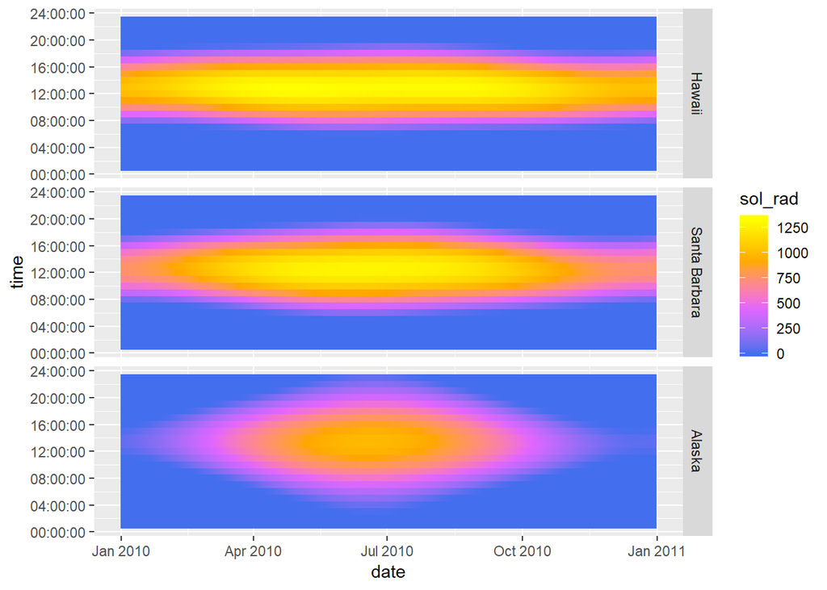

```r
solar_gg <- ggplot(solar_tidy, aes (x = date, y = time)) +
  geom_tile(aes(fill = sol_rad)) +
  scale_fill_gradientn(colors = c("royalblue2", "mediumorchid1", "orange", "yellow")) +
  scale_y_time() +
  facet_grid(site ~ .)

solar_gg
```

# PART 4. gganimate example: total aquaculture production (metric tons) for United States, Brazil, Chile, and Ecuador

1. Get the data, and do some wrangling:

```r
aq_df <- read_csv("aq_wb.csv")
aq_df
```

```
## # A tibble: 264 x 62
##    country code  indicator ind_code `1960` `1961` `1962` `1963` `1964`
##    <chr>   <chr> <chr>     <chr>     <int>  <int>  <int>  <int>  <int>
##  1 Aruba   ABW   Aquacult~ ER.FSH.~     NA     NA     NA     NA     NA
##  2 Afghan~ AFG   Aquacult~ ER.FSH.~     NA     NA     NA     NA     NA
##  3 Angola  AGO   Aquacult~ ER.FSH.~     NA     NA     NA     NA     NA
##  4 Albania ALB   Aquacult~ ER.FSH.~      0      0      0      0      0
##  5 Andorra AND   Aquacult~ ER.FSH.~     NA     NA     NA     NA     NA
##  6 Arab W~ ARB   Aquacult~ ER.FSH.~   4600   5200   5200   6000   7000
##  7 United~ ARE   Aquacult~ ER.FSH.~      0      0      0      0      0
##  8 Argent~ ARG   Aquacult~ ER.FSH.~      0      0      1      2      4
##  9 Armenia ARM   Aquacult~ ER.FSH.~     NA     NA     NA     NA     NA
## 10 Americ~ ASM   Aquacult~ ER.FSH.~     NA     NA     NA     NA     NA
## # ... with 254 more rows, and 53 more variables: `1965` <int>,
## #   `1966` <int>, `1967` <int>, `1968` <int>, `1969` <int>, `1970` <int>,
## #   `1971` <int>, `1972` <int>, `1973` <int>, `1974` <int>, `1975` <int>,
## #   `1976` <int>, `1977` <int>, `1978` <int>, `1979` <int>, `1980` <int>,
## #   `1981` <int>, `1982` <int>, `1983` <int>, `1984` <dbl>, `1985` <dbl>,
## #   `1986` <dbl>, `1987` <dbl>, `1988` <dbl>, `1989` <dbl>, `1990` <dbl>,
## #   `1991` <dbl>, `1992` <dbl>, `1993` <dbl>, `1994` <dbl>, `1995` <dbl>,
## #   `1996` <dbl>, `1997` <dbl>, `1998` <dbl>, `1999` <dbl>, `2000` <dbl>,
## #   `2001` <dbl>, `2002` <dbl>, `2003` <dbl>, `2004` <dbl>, `2005` <dbl>,
## #   `2006` <dbl>, `2007` <dbl>, `2008` <dbl>, `2009` <dbl>, `2010` <dbl>,
## #   `2011` <dbl>, `2012` <dbl>, `2013` <dbl>, `2014` <dbl>, `2015` <dbl>,
## #   `2016` <dbl>, `2017` <chr>
```

```r
aq_tidy <- aq_df %>%
  filter(country == "Brazil" |
           country == "Chile" |
           country == "Ecuador" |
           country == "United States") %>%
  gather(year, aq_prod, `1960`:`2016`) %>%
  filter(year >= 1990) %>%
  mutate(aq_mil = aq_prod/1000000) %>%
  select(country, year, aq_mil)

aq_tidy
```

```
## # A tibble: 108 x 3
##    country       year  aq_mil
##    <chr>         <chr>  <dbl>
##  1 Brazil        1990  0.0205
##  2 Chile         1990  0.0705
##  3 Ecuador       1990  0.0777
##  4 United States 1990  0.316
##  5 Brazil        1991  0.0234
##  6 Chile         1991  0.105
##  7 Ecuador       1991  0.107
##  8 United States 1991  0.363
##  9 Brazil        1992  0.0298
## 10 Chile         1992  0.116
## # ... with 98 more rows
```

2. Read in the fish.png as ‘fish’

```r
fish <- "fish.png"
```

3. Make a graph…with gganimate!

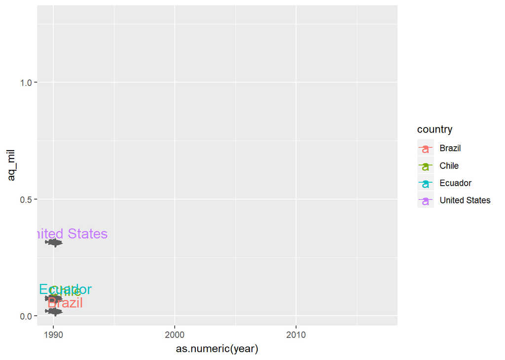

```r
aq_plot <- ggplot(aq_tidy, aes(x = as.numeric(year), y=aq_mil, group = country)) +
  geom_line(aes(color = country)) +
  geom_point(aes(color = country)) +
  geom_image(aes(image = fish)) +
  geom_text(aes(label = country, color = country), position = position_nudge(y = 0.04, x =1), size = 5) +
  transition_reveal(country, as.numeric(year))

aq_plot
```